# Desmognathus figure review

Manifest-driven visual critique gallery

This page is a visual-review surface, not a second figure authority. It reads `Publication/figures/FIGURE_MANIFEST.csv` and `Publication/figures/AUXILIARY_FIGURE_MANIFEST.csv` in row order and displays the exact current review PNG for every record. Declared final widths are preserved proportionally, so a 120-mm figure appears narrower than a 180-mm figure.

**Current gallery:** 7 numbered or supplemental figures; 5 auxiliary review figures; widest declared figure: 180 mm.

**Figure 1 is the integrated 21-species overview.** A topology-only species tree aligns reproductive strategy, conditional genome size, dnaPipeTE composition, and low-divergence RepeatMasker signal in one fixed row order.

**Unresolved tree provenance.** The source tree was supplied directly by Alex Pyron, but its publication or archive identifier, calibration method, and branch-length provenance remain unresolved. Numbered Figures 1, 4, and 5 therefore show topology only. Supplied-time displays remain quarantined as auxiliary review figures and are not independent validation of the calibration.

**Figure 2 Bonsai boundary.** The rooted Bonsai Newick is a TE-composition representation, not a species phylogeny; its display root has no phylogenetic meaning. Reproductive strategy was annotated after initial PCA review, and feature resampling perturbs correlated compositional coordinates rather than resampling biological specimens. S09–S11 retain the PCA geometry as a supplementary audit.

**Wang-style integrated TE-history candidate boundary.** This is a review candidate, not a numbered manuscript figure. Six representatives are selected deterministically from the overlap21 genome-size distribution plus the *D. fuscus* anchor. Repeat proportions are fractions of aligned RepeatMasker hit bp, not genome occupancy; divergence bins are not insertion ages.

**Wang-style TE-diversity candidate boundary.** Conditional genome sizes are assembly-anchored IOD-derived estimates. Reproductive-strategy panels are post-hoc descriptive strata. The two direct developers are shown without a regression because n = 2; the other six panels use Pagel-lambda PGLS fits.

**Cross-study TE-diversity boundary.** Descriptive cross-study context only; no pooled regression or hypothesis test. Wang et al. (2025) values are the published top-10 TE-superfamily indices from Dryad (dataset DOI 10.5061/dryad.zpc866tkv; article DOI 10.1038/s42003-025-08127-3; CC0-1.0), generated from RepeatModeler/RepeatMasker annotations. Current *Desmognathus* top-10 indices are reclosed calculations from dnaPipeTE compositions; the pipelines are different and not method-harmonized. Current genome sizes are conditional *D. fuscus* assembly-anchored estimates, not direct species C-values.

# Critique checklist

- **Narrative and material:** Does every panel earn its place and support the intended manuscript claim?
- **Cross-figure coherence:** Do repeated concepts use the same visual grammar without implying false equivalence?
- **Typography:** Are font family, size, weight, italics, symbols, and panel tags consistent and legible at final size?
- **Color:** Are hues meaningful, high-contrast, color-vision accessible, and reinforced by shape or line type?
- **Marks and uncertainty:** Are points, lines, intervals, raw observations, and summary estimates visually distinct?
- **Axes and labels:** Are units, transformations, abbreviations, tick density, and scientific names clear?
- **Spacing:** Are gutters, panel proportions, margins, legend placement, and whitespace balanced?
- **Reference-paper fit:** Do framing, density, hierarchy, and annotation feel like one visual family?
- **Legend and alt text:** Can each figure be understood without manuscript body text?
- **Phylogeny:** Are topology, tip order, time direction, scale, and provenance boundary immediately clear?

# Figure gallery

## Figure 1

Final size: 180 × 165 mm Font: Nimbus Sans Target text: ≥7 pt Datasets: S04;S12;S24;S42;te_order_composition;te_superfamily_composition;trees/desmo900dated_source46.tre Status: `main_candidate_integrated_biological_overview`

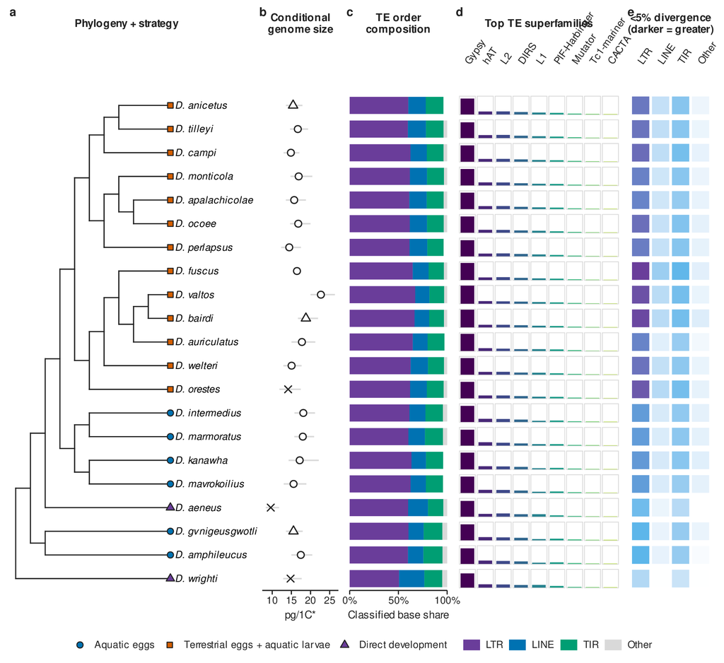

**Legend.** Twenty-one species are aligned in one fixed phylogenetic order across reproductive strategy, conditional genome size, dnaPipeTE composition, and RepeatMasker low-divergence signal. Panel a is a topology-only prune of the supplied species tree; branch lengths are omitted because the tree’s publication, calibration, and time provenance remain unresolved. Panel b shows D. fuscus assembly-anchored IOD-derived pg/1C estimates and conditional intervals; crosses flag the prespecified image-quality balance caution and triangles flag one-image, one-animal support. These are not independently measured species C-values, and intervals exclude anchor uncertainty. Panel c shows broad-order shares of classified dnaPipeTE aligned bases. Panel d shows the same assay at the nine most abundant superfamilies, with bar height on one common scale. Panel e shows the RepeatMasker-aligned fraction below 5% sequence divergence for LTR, LINE, TIR, and all other annotations. dnaPipeTE composition and RepeatMasker landscape denominators are distinct; neither is genome occupancy, and divergence is not insertion age.

**Alt text.** A 21-tip topology-only species tree and reproductive-strategy rail align with conditional genome-size intervals, broad dnaPipeTE order composition, nine dnaPipeTE superfamily tracks, and a four-order heatmap of low-divergence RepeatMasker signal. Every row follows the same supplied-tree order, and symbols expose genome-size support cautions.

## Figure 2

Final size: 180 × 142 mm Font: Nimbus Sans Target text: ≥7 pt Datasets: S42;S43;te_pca_trait_association_tests;trees/te34_bonsai_composition_tree_with_feature_support.nwk Status: `main_candidate_bonsai_with_pca_supplementary_audit`

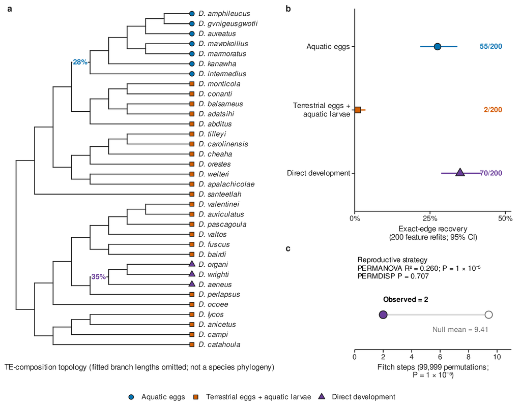

**Legend.** Panel a shows the 34-tip Bonsai topology fitted to the retry-averaged 24-superfamily CLR matrix. Branch lengths are deliberately omitted from this main display so the full topology remains legible; the display root has no phylogenetic meaning, and this is not a species phylogeny. Tip symbols show the post-hoc reproductive-strategy annotation, including D. fuscus as terrestrial eggs with aquatic larvae. Only the exact aquatic-egg and direct-development edges are labeled with feature-resampling split support. Panel b shows exact-edge recovery with 95% binomial intervals across 200 bounded feature-resampling refits: aquatic eggs 55/200, direct development 70/200, and terrestrial eggs with aquatic larvae 2/200. Panel c shows the global strategy-label localization (2 observed Fitch steps versus a 9.41-step permutation-null mean; 99,999 permutations, P = 0.00001) and the post-hoc Aitchison-distance association (PERMANOVA R² = 0.260, P = 0.00001; PERMDISP P = 0.707). Ordinary label permutations are not phylogenetically corrected, and feature resampling perturbs compositional coordinates rather than biological specimens; the result is strategy-associated compositional structure, not evidence for discrete natural clusters or causation. Exact fitted branch lengths and PCA outputs remain supplementary audits.

**Alt text.** Panel a is a topology-only TE-composition tree for 34 species with all tips colored and shaped by post-hoc reproductive strategy; aquatic-egg species and the three direct developers localize to exact edges. Panel b gives exact-edge recovery estimates and binomial intervals from 200 feature refits. Panel c contrasts two observed Fitch steps with a permutation-null mean of 9.41 and summarizes the post-hoc multivariate association and dispersion diagnostic.

## Figure 3

Final size: 180 × 150 mm Font: Nimbus Sans Target text: ≥7 pt Datasets: S12;S13 Status: `main_candidate`

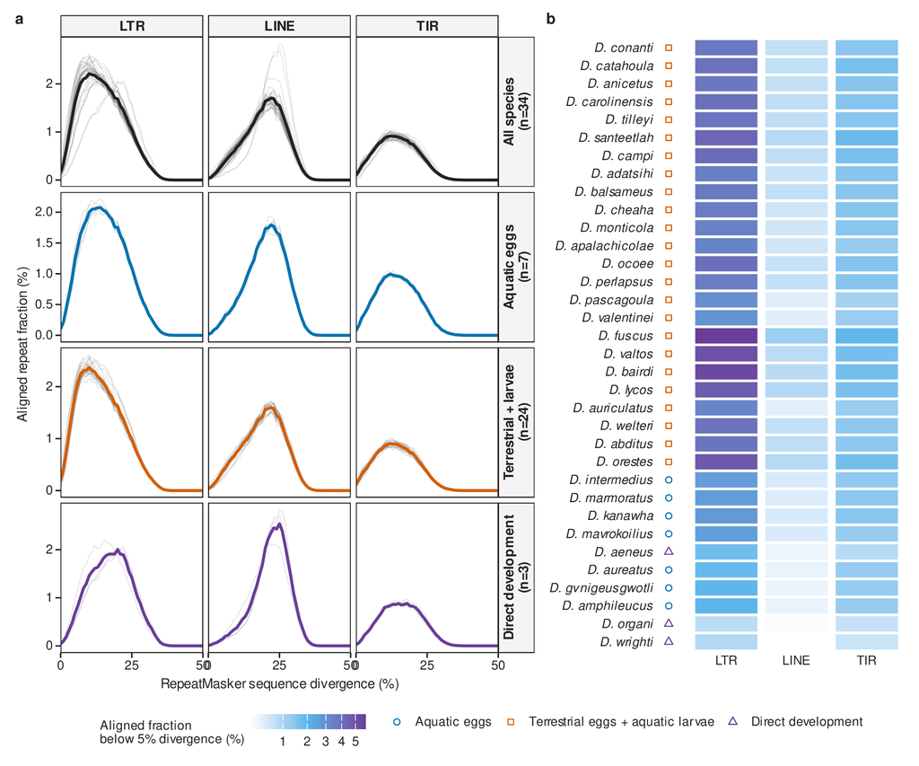

**Legend.** RepeatMasker divergence profiles reveal both a shared low-divergence pulse and substantial among-species heterogeneity. Panel a shows LTR, LINE, and TIR profiles for all 34 species and the three post-hoc reproductive-strategy strata. Thin gray curves are individual species and colored curves are equal-weight group means after zero-filling absent category/bin combinations; facet y scales are independent, so magnitudes must be read from each numeric axis. The strata are descriptive and not a phylogenetically corrected test. Panel b shows each species’ aligned-repeat fraction below 5% divergence for the same three orders, with species held in the shared supplied-tree order and strategy shown redundantly by color and shape. RepeatMasker divergence is not an insertion age, and aligned-repeat fractions are not genome occupancy.

**Alt text.** Panel a is a four-by-three matrix of individual-species and mean LTR, LINE, and TIR divergence profiles for all species and three reproductive strategies. Panel b is a 34-species heatmap of the aligned fraction below five percent divergence for those orders, with species in phylogenetic order and a reproductive-strategy rail.

## Figure 4

Final size: 180 × 150 mm Font: Nimbus Sans Target text: ≥7 pt Datasets: S14;S15;S16;S17;trees/desmo900dated_source46.tre Status: `sensitivity_only_not_ectopic_rate`

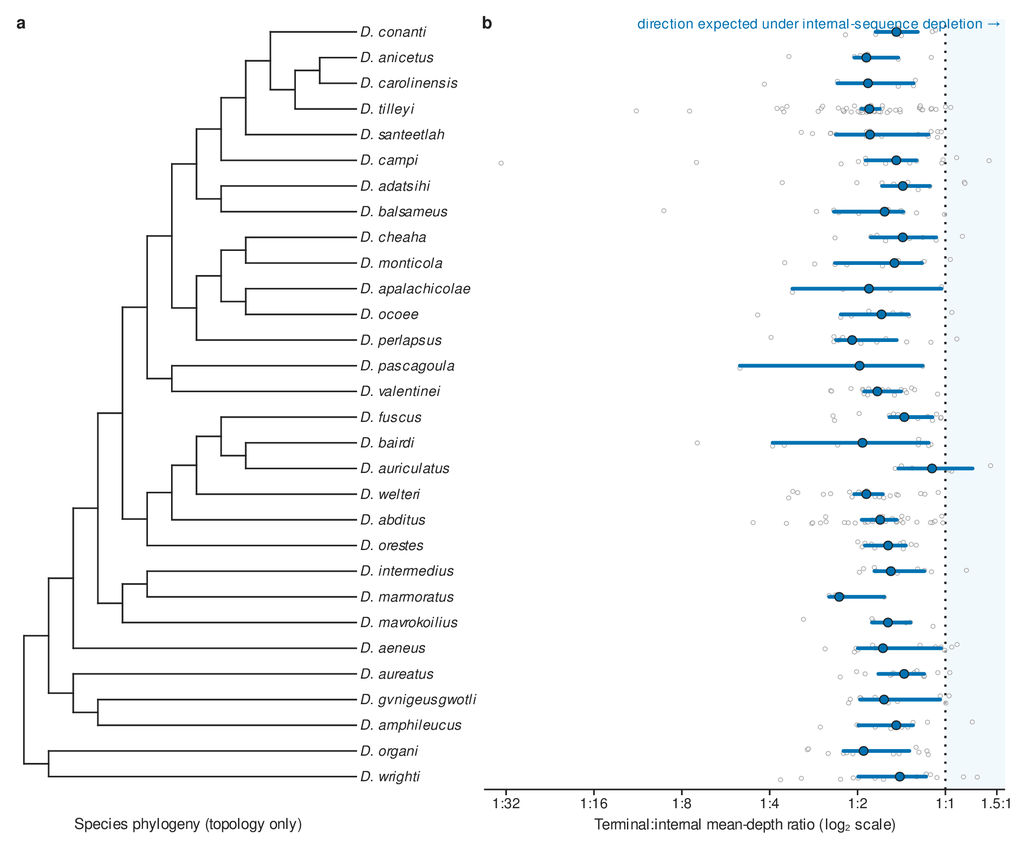

**Legend.** Panel a shows a topology-only 30-tip prune of the supplied 46-tip species tree; branch lengths are omitted because its publication or archive identifier, calibration method, and branch-length provenance remain unresolved. Species rows are derived from the plotted tip-y order and therefore follow the shared canonical phylogenetic order. Panel b shows the zero-aware terminal:internal LTR depth proxy across the exact 380-element primary branch. Hollow points are element-level observations, blue points are species medians, and horizontal blue intervals are 2,000-replicate element-bootstrap intervals. Elements are not biological replicates, and intervals are conditional on the recovered elements and sequencing resources. Elements were retained inclusively within each species’ two-sided 1.5-IQR fences and only when the left LTR, right LTR, and internal region each had at least 80% positive-depth coverage. The primary branch derives from 408 LTR/Gypsy candidates at least 3,000 bp long with at least five correctly parsed TEsorter domain annotations. The dotted line marks equal terminal and internal mean depth (1:1); values to its right point in the direction expected under internal-sequence depletion. The tree supplies context and ordering only; this mapping/deletion-footprint proxy is not a phylogenetic analysis or an estimate of an ectopic-recombination, solo-LTR, or DNA-loss rate.

**Alt text.** Panel a shows a topology-only species tree pruned to the 30 LTR species. Panel b aligns the same 30 phylogenetic rows with 380 hollow element observations, species medians, and horizontal bootstrap intervals on a log2 terminal:internal ratio axis. A dotted vertical line marks equal terminal and internal depth, and light blue shading marks the direction expected under internal-sequence depletion.

## Figure 5

Final size: 180 × 150 mm Font: Nimbus Sans Target text: ≥7 pt Datasets: S04;S18;S19;S20;S24;organismal_traits;trees/desmognathus_time_tree_path24_v1.nwk Status: `main_candidate_integrated_phylogeny_and_cellular_traits`

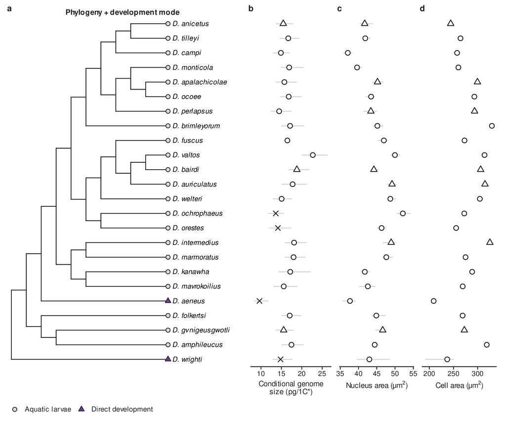

**Legend.** Twenty-four species are aligned across a topology-only prune of the supplied species tree, development mode, conditional genome size, and reviewed upper-tail erythrocyte nucleus and cell areas. Branch lengths are omitted because the species tree’s publication, calibration, and time provenance remain unresolved. Genome-size points are D. fuscus assembly-anchored IOD-derived estimates; triangles identify one-image, one-animal support and crosses flag the prespecified image-quality balance caution. These are not independently measured species C-values, and intervals exclude anchor uncertainty. Nucleus and cell points are species medians from the 1,152 accepted reviewed pairs retained in S18; triangles identify the seven species represented by one animal. All intervals are conditional on observed images/animals and do not represent population-level uncertainty.

**Alt text.** A topology-only tree for 24 Desmognathus species aligns development mode with conditional genome-size, nucleus-area, and cell-area forest plots. All tracks share one phylogenetic row order, and point shapes expose single-animal and image-quality support cautions.

## Figure 6

Final size: 180 × 92 mm Font: Nimbus Sans Target text: ≥7 pt Datasets: S04;S19;S24;S26 Status: `sensitivity_only_conditional_genome_size`

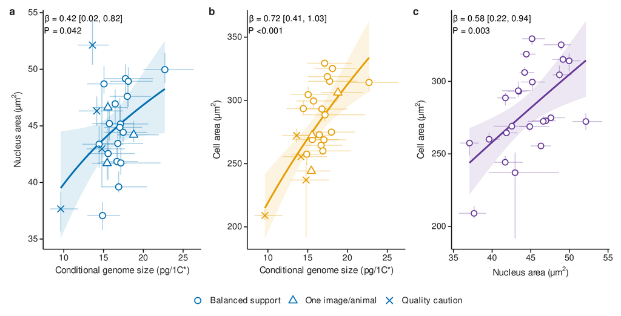

**Legend.** Conditional genome size, nucleus area, and cell area are positively associated in Pagel-lambda PGLS sensitivity fits. Circles identify balanced multiple-image support, triangles identify estimates from one image and animal, and crosses identify four species that fail the declared quality-balance gate. Bars are conditional measurement-bootstrap intervals; lines and ribbons are PGLS fits and model confidence intervals. Genome size is the released D. fuscus assembly-anchored pg/1C estimate, not a direct independently measured species C-value.

**Alt text.** Three scatterplots show conditional genome size versus nucleus area, conditional genome size versus cell area, and nucleus area versus cell area, each with measurement intervals and a phylogenetically corrected fitted line; point shape exposes single-image and quality-balance limitations in the genome-size panels.

## Figure 7

Final size: 180 × 108 mm Font: Nimbus Sans Target text: ≥7 pt Datasets: S04;S30-S36 Status: `sensitivity_only_conditional_genome_size_no_causal_claim`

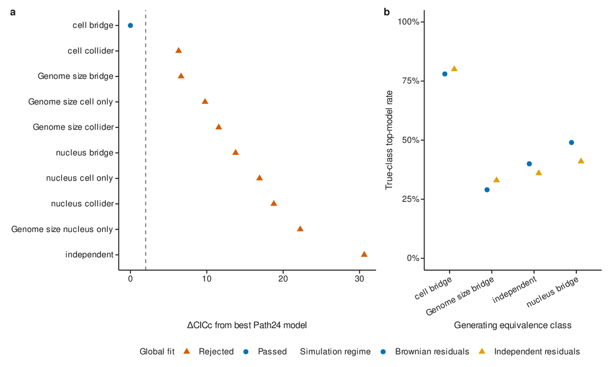

**Legend.** The finalized 24-species conditional genome-size path-model ranking favors one Markov-equivalence class, while simulation recovery varies by generating class and residual regime. Delta CICc is relative to the best Path24 model; color and shape record the global d-separation fit gate. Genome size is the released D. fuscus assembly-anchored pg/1C estimate, not a direct independently measured species C-value. These exploratory results do not orient causal arrows within an equivalence class.

**Alt text.** The left panel compares candidate conditional genome-size equivalence classes in the finalized 24-species analysis by delta CICc and global-fit status. The right panel shows true-class recovery rates under independent and Brownian residual simulations; genome-size labels denote the released conditional D. fuscus assembly-anchored pg/1C scale.

Record critiques by figure ID and panel letter. Changes belong in the shared ggplot theme or production figure builder, not in this gallery or its embedded images.

# Auxiliary review figures

## Wang-style integrated TE content and proliferation candidate

Final size: 180 × 145 mm Font: Nimbus Sans Target text: ≥7 pt Datasets: S04;S08;S12;S42;trees/desmo900dated_source46.tre Status: `auxiliary_review_candidate_wang_style_six_representatives` Asset: `Wang_style_integrated_TE_history_candidate.png`

**Boundary.** Review candidate, not a numbered manuscript figure. Six representatives are selected deterministically from overlap21: nearest to the 0%, 20%, 40%, 80%, and 100% conditional genome-size quantiles plus the D. fuscus anchor. Conditional genome size is IOD-derived and not a direct species C-value. Repeat proportions are fractions of aligned RepeatMasker hit bp, not genome occupancy; divergence bins are not insertion ages.

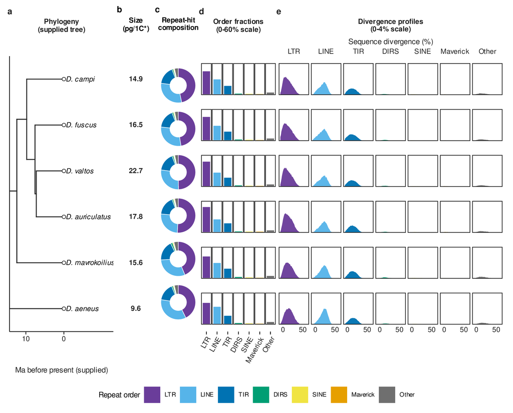

**Legend.** Panel A prunes the supplied dated species tree to six deterministic overlap21 representatives. Panel B gives conditional D. fuscus-anchored genome size. Panels C-D show aligned-repeat composition for the six most abundant named biological orders plus Other, which includes the Unclassified annotation. Panel E shows zero-filled RepeatMasker divergence profiles on one common percentage scale.

**Alt text.** Six Desmognathus species are aligned across a dated phylogeny, conditional genome-size values, repeat-composition donuts, repeat-composition bars, and a seven-column grid of divergence profiles. Species rows and all data tracks share the same phylogenetic order.

## Wang-style TE diversity and genome-size candidate

Final size: 180 × 105 mm Font: Nimbus Sans Target text: ≥7 pt Datasets: S04;S08;S42;trees/desmo900dated_source46.tre Status: `auxiliary_review_candidate_wang_style_pgls_post_hoc_strata` Asset: `Wang_style_TE_diversity_genome_size_candidate.png`

**Boundary.** Review candidate, not a numbered manuscript figure. All genome-size values are conditional D. fuscus assembly-anchored IOD-derived estimates, not direct species C-values. Reproductive-strategy panels are post-hoc descriptive strata. The two direct developers are shown without a regression because n = 2.

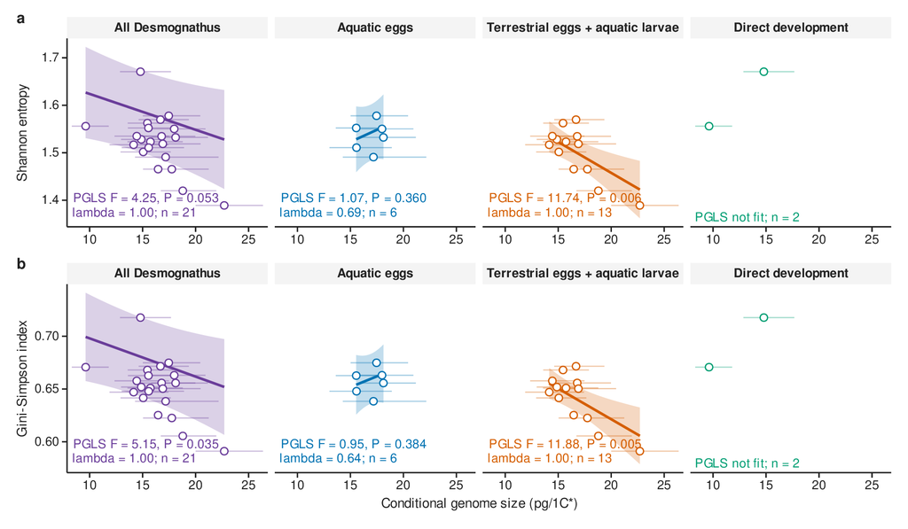

**Legend.** Rows show the canonical top-ten-superfamily Shannon entropy and Gini-Simpson index. Columns show all 21 overlap species, six aquatic-egg species, 13 terrestrial-egg species with aquatic larvae, and two direct developers. Hollow points are species and horizontal bars are conditional genome-size intervals. Lines and bands are Pagel-lambda PGLS fits and coefficient confidence bands; the n = 2 direct-development panels intentionally have no fit.

**Alt text.** Two aligned rows of four framed scatterplots show Shannon and Gini-Simpson diversity against conditional genome size for all Desmognathus and three reproductive strategies. PGLS statistics appear inside six panels; the two direct-development panels show only their two observations and state that a fit was not estimated.

## Path24 development and phenotype reference

Final size: 180 × 165 mm Font: Nimbus Sans Target text: ≥7 pt Datasets: S04;S19;S38;S39;organismal_traits Status: `auxiliary_review_only_descriptive` Asset: `Path24_development_and_trait_phylogeny_reference.png`

**Boundary.** Descriptive review only. D. organi is absent from Path24 and is not imputed. The genome-size track uses conditional D. fuscus assembly-anchored pg/1C estimates, not direct independently measured species C-values. Tree time is shown as supplied; publication and calibration provenance remain unresolved.

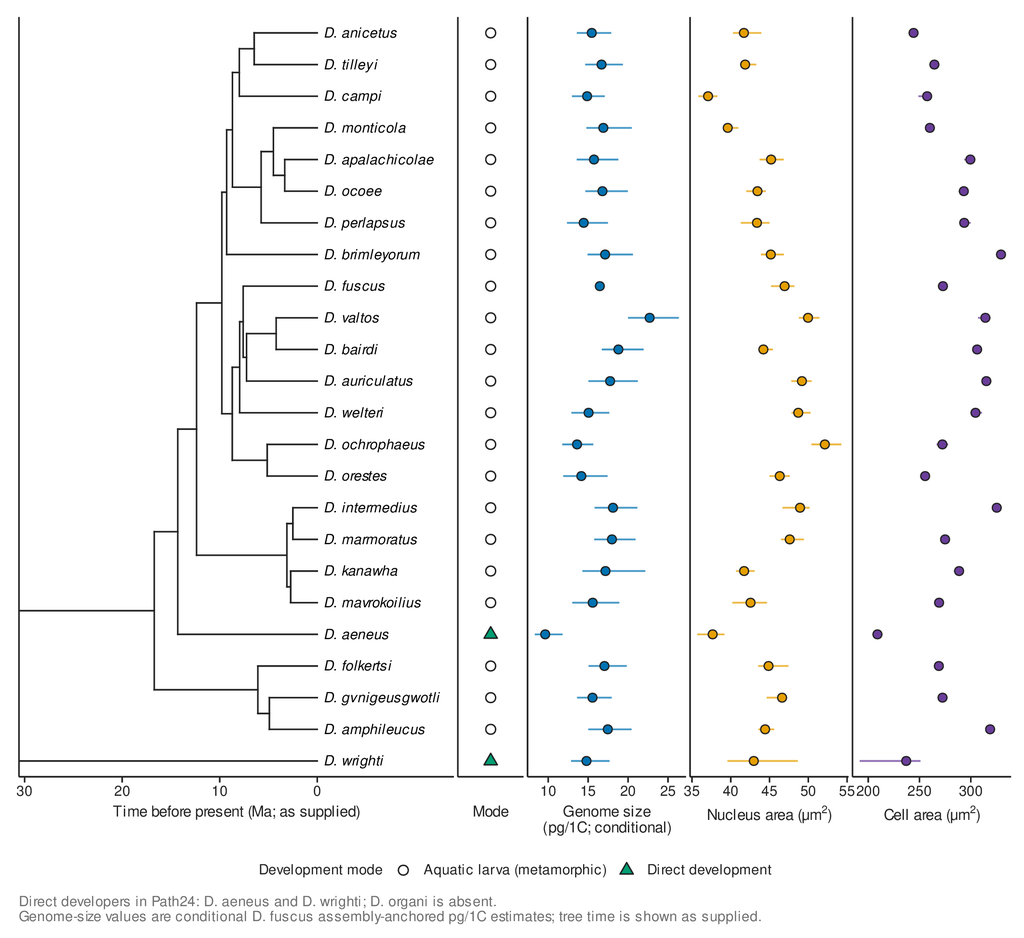

**Legend.** The supplied 24-tip Path24 dated tree is aligned to development mode and conditional D. fuscus-anchored genome-size, reviewed nucleus-area, and reviewed cell-area estimates. Horizontal bars are released conditional measurement intervals. The two sampled direct developers are D. aeneus and D. wrighti; the other 22 Path24 species have aquatic larvae and undergo metamorphosis. This is a descriptive visualization, not a development-mode test.

**Alt text.** A dated phylogeny for 24 Desmognathus species is aligned with a development-mode marker and forest-plot tracks for conditional genome size, nucleus area, and cell area. D. aeneus and D. wrighti are the two direct developers represented in Path24.

## Path DAG equivalence-class reference

Final size: 180 × 220 mm Font: Nimbus Sans Target text: ≥7 pt Datasets: S04;S30;candidate_dags Status: `auxiliary_review_only_conditional_genome_size_no_causal_claim` Asset: `Path_DAG_equivalence_class_reference.png`

**Boundary.** Not a numbered manuscript figure. The DAG node is Genome size on the conditional D. fuscus assembly-anchored pg/1C analysis, not a direct species C-value measurement. The same released genome-size scale is used consistently across all scored classes. The 10 testable equivalence classes do not orient a unique causal arrow; the saturated 6-member class is not shown and remains unscored because it has no d-separation claim.

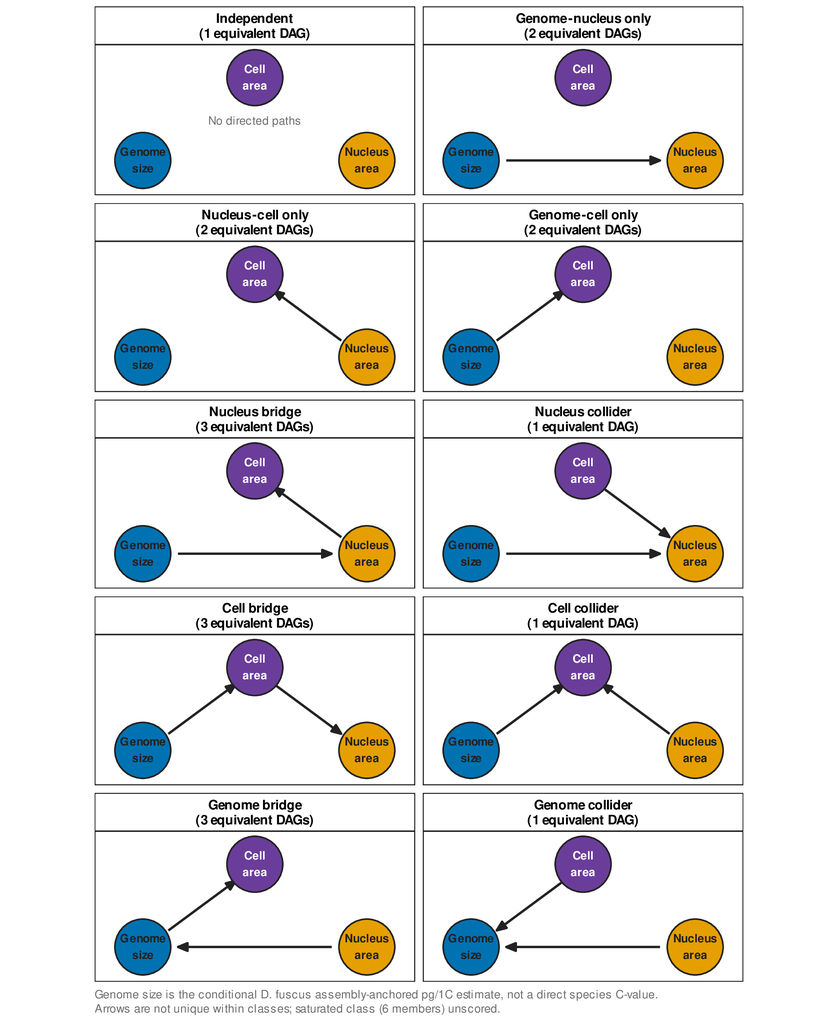

**Legend.** One representative DAG is shown for each of the 10 testable Path24 equivalence classes. Genome size denotes the conditional D. fuscus assembly-anchored pg/1C estimate, not a direct species C-value measurement. Equivalent arrow orientations are omitted, and the saturated 6-member class remains unscored.

**Alt text.** Ten boxed path diagrams connect Genome size, Nucleus area, and Cell area with arrows. Each is one representative of a testable equivalence class, not a uniquely oriented causal graph; the six-member saturated class is omitted as unscored.

## Cross-study TE-diversity reference (Wang et al. 2025)

Final size: 180 × 158 mm Font: Nimbus Sans Target text: ≥7 pt Datasets: S41 Status: `auxiliary_review_only_cross_study_context_non_harmonized` Asset: `Wang2025_cross_study_TE_diversity_reference.png`

**Boundary.** Descriptive cross-study context only; no pooled regression or hypothesis test is shown. Wang et al. 2025 published top-10 TE-superfamily indices are exact CC0-1.0 Dryad values (dataset DOI 10.5061/dryad.zpc866tkv; article DOI 10.1038/s42003-025-08127-3) produced from RepeatModeler/RepeatMasker annotations. Current top-10 indices are reclosed calculations from dnaPipeTE compositions. The pipelines are different and not method-harmonized. Current genome sizes are conditional D. fuscus assembly-anchored estimates, not direct species C-values.

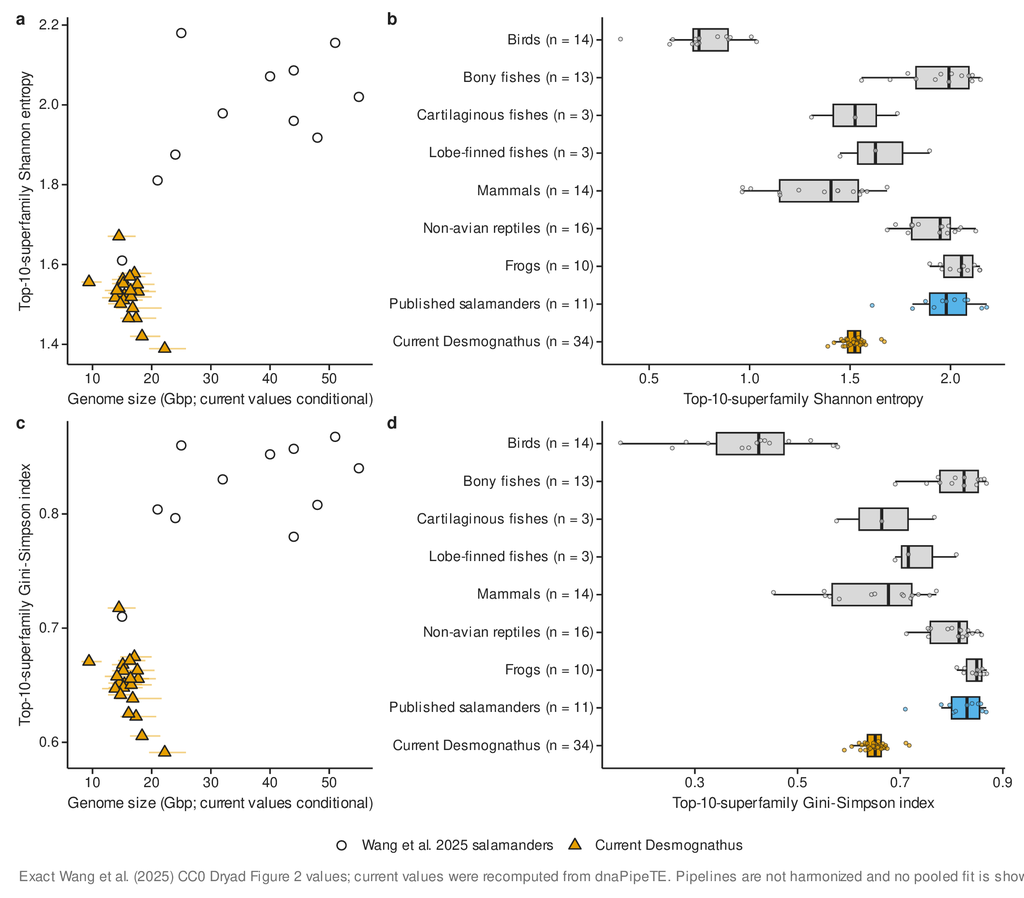

**Legend.** Panels A and C show genome size against top-ten-superfamily Shannon entropy and the Gini-Simpson index for 11 published salamanders and 21 current Desmognathus species. Panels B and D show the exact published vertebrate-group distributions beside all 34 current Desmognathus summaries. Wang et al. values come from RepeatModeler/RepeatMasker; current values come from dnaPipeTE. The comparison is descriptive and has no pooled fit.